# Laboratório 4: Visualização de Dados com **plotnine**

### Importe o conjunto de dados diamonds, cujo arquivo está disponível no website da disciplina.

```python
import os
import pandas as pd
from plotnine import *
from plotnine.data import diamonds
```

```python
from datetime import datetime
agora = datetime.now()

print("Arquivo compilado em:", agora.strftime("%d/%m/%Y %H:%M:%S"))
```

```
Arquivo compilado em: 30/10/2025 11:39:46
```

### Inspeção Inicial

```python
print(diamonds.head())
```

```
   carat      cut color clarity  depth  table  price     x     y     z
0   0.23    Ideal     E     SI2   61.5   55.0    326  3.95  3.98  2.43
1   0.21  Premium     E     SI1   59.8   61.0    326  3.89  3.84  2.31
2   0.23     Good     E     VS1   56.9   65.0    327  4.05  4.07  2.31
3   0.29  Premium     I     VS2   62.4   58.0    334  4.20  4.23  2.63
4   0.31     Good     J     SI2   63.3   58.0    335  4.34  4.35  2.75
```

```python
print(diamonds.shape)
```

```
(53940, 10)
```

### Crie uma visualização de dados que descreva a associação existente entre as variáveis peso (carat) e preço (price). Que ações você tomou para garantir que você produziu um gráfico de boa qualidade? Escreva um parágrafo comunicando os seus achados.

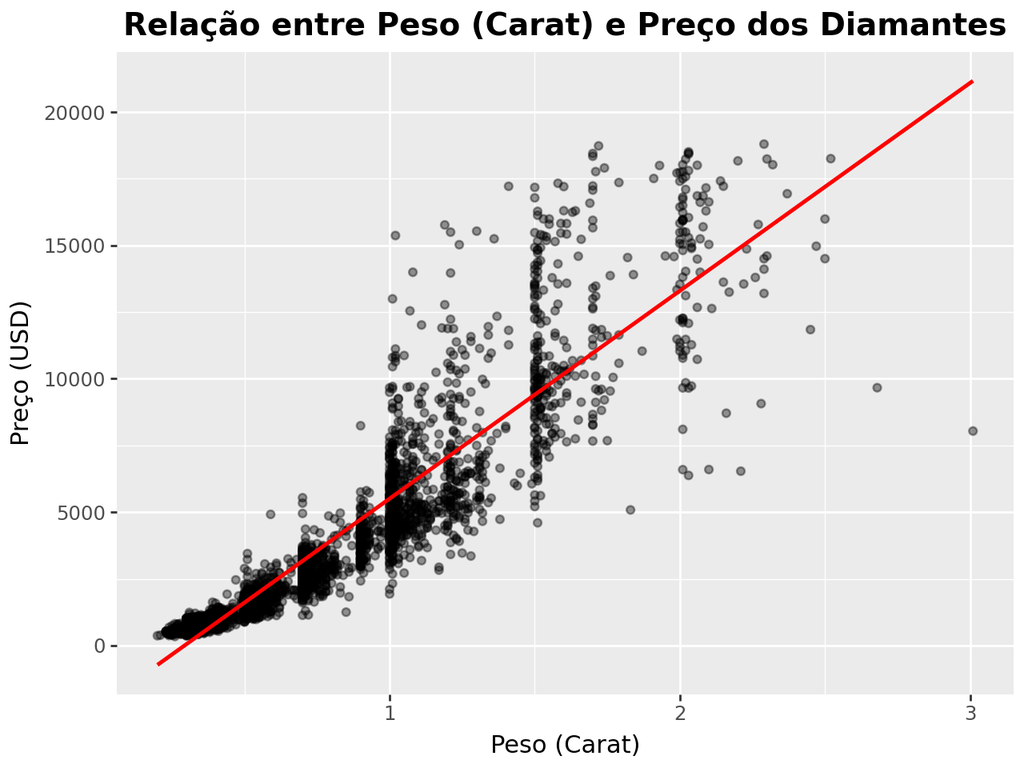

```python
(
    ggplot(diamonds.sample(3000), aes(x='carat', y='price')) +
    geom_point(alpha=0.4) +
    geom_smooth(method='lm', se=False, color= "red") +
    labs(
        title='Relação entre Peso (Carat) e Preço dos Diamantes',
        x='Peso (Carat)',
        y='Preço (USD)'
    ) +
    theme_gray() +
    theme(
    plot_title=element_text(weight='bold', size= 14)
)
)
```

A análise da relação entre o peso dos diamantes (carat) e o preço mostra uma associação positiva clara: conforme o peso aumenta, o preço também cresce de forma significativa. A dispersão dos pontos sugere que o preço não depende apenas do peso, pois há grande variação para um mesmo valor de carat, possivelmente influenciada por outros atributos de qualidade (como cor, corte e clareza). Ainda assim, a linha de tendência confirma que o peso é um importante fator determinante no valor de mercado dos diamantes.

### A relação identificada na questão anterior é a mesma relação presente nos diferentes cortes de diamantes? Crie uma visualização que demonstre seus achados eficientemente. Descreva sua conclusão em um parágrafo.

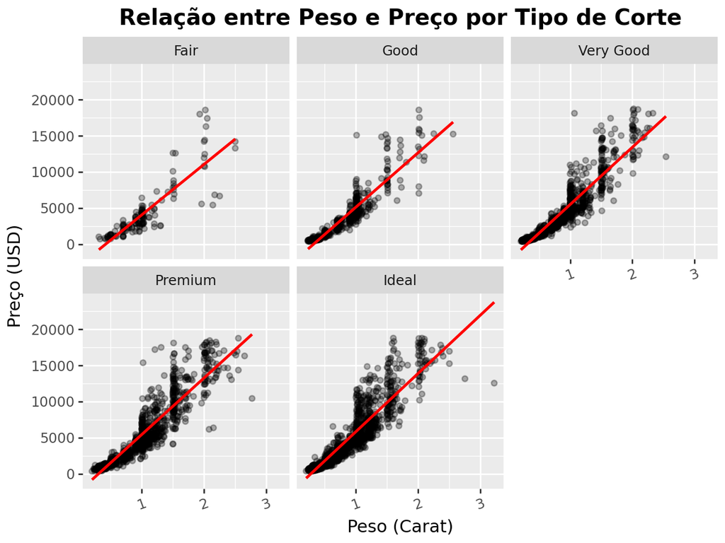

```python
(
    ggplot(diamonds.sample(5000), aes(x='carat', y='price')) +
    geom_point(alpha=0.3) +
    geom_smooth(method='lm', se=False, color='red') +
    facet_wrap('~cut') +
    labs(
        title='Relação entre Peso e Preço por Tipo de Corte',
        x='Peso (Carat)',
        y='Preço (USD)'
    ) +
    theme_gray() +
    theme(
        plot_title=element_text(weight='bold', size=14),
        axis_text_x=element_text(rotation=20)
    )
)
```

A associação positiva entre peso (carat) e preço permanece em todos os tipos de corte: diamantes mais pesados continuam sendo significativamente mais caros. Contudo, há diferenças claras no valor agregado por corte. Cortes como Ideal e Premium apresentam preços mais elevados para um mesmo peso, indicando que além do tamanho, a qualidade do corte impacta o valor de mercado. Já os cortes Fair e Good demonstram menor valorização por peso, refletindo menor qualidade óptica. Portanto, embora o peso seja um importante determinante do preço, a influência do corte se mantém relevante e modifica a inclinação dessa relação.

### Crie uma visualização que mostre a relação entre preço e peso do diamante, considerando as diferentes combinações de qualidade de corte, cor e clareza do diamante. Quais foram as dificuldades encontradas? A relação entre preço e peso é a mesma para diferentes configurações de diamantes?

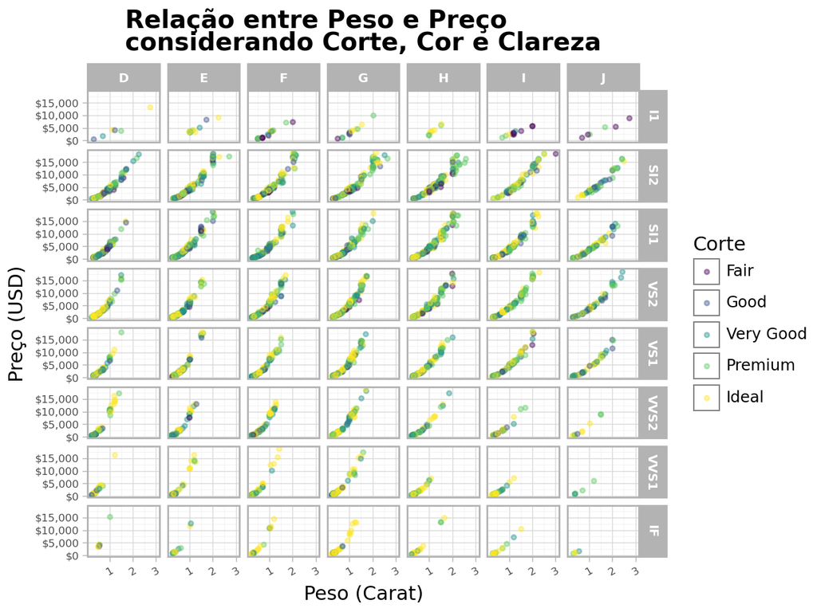

```python
(
    ggplot(diamonds.sample(5000), aes(x='carat', y='price', color='cut')) +
    geom_point(alpha=0.4, size=1) +
    facet_grid('clarity ~ color') +
    scale_y_continuous(labels=lambda l: ["${:,.0f}".format(v) for v in l]) +
    labs(
        title='Relação entre Peso e Preço \nconsiderando Corte, Cor e Clareza',
        x='Peso (Carat)',
        y='Preço (USD)',
        color='Corte'
    ) +
    theme_light() +
    theme(
        plot_title=element_text(weight='bold', size=14),
        axis_text_x=element_text(rotation=30, size=6),
        axis_text_y=element_text(size=6),
        strip_text=element_text(weight='bold', size=7),
    )
)
```

A relação positiva entre peso e preço permanece presente em todas as combinações de características analisadas. Entretanto, a valorização por peso não é uniforme. Diamantes com melhor corte (Ideal/Premium), melhor clareza e melhor cor apresentam preços mais altos para o mesmo peso, enquanto diamantes mais inclusos, amarelados ou com corte inferior são menos valorizados. Isso indica que, embora o peso seja um forte determinante do preço, a qualidade física e óptica do diamante altera significativamente o retorno financeiro por quilate. Assim, a relação entre preço e peso não é a mesma entre as diferentes configurações de diamantes.